# Risk Factor Analysis

## Outcome Variable

**Outcome Variable:** ever_swasted

## Predictor Variables

**Intervention Variable:** feducyrs

**Adjustment Set:**

- arm
- W_mage
- meducyrs
- hhwealth_quart
- W_mhtcm
- W_mwtkg
- W_mbmi
- W_gagebrth
- W_birthwt
- W_birthlen
- single
- delta_W_mage
- delta_meducyrs
- delta_hhwealth_quart
- delta_W_mhtcm
- delta_W_mwtkg
- delta_W_mbmi
- delta_W_gagebrth
- delta_W_birthwt
- delta_W_birthlen
- delta_single

## Stratifying Variables

The analysis was stratified on these variable(s):

- agecat
- studyid
- country

## Data Summary

| agecat | studyid | country | feducyrs | ever_swasted | n_cell | n |
| --- | --- | --- | --- | --- | --- | --- |
| 0-24 months | COHORTS | GUATEMALA | High | 0 | 214 | 1234 |
| 0-24 months | COHORTS | GUATEMALA | High | 1 | 17 | 1234 |
| 0-24 months | COHORTS | GUATEMALA | Low | 0 | 521 | 1234 |
| 0-24 months | COHORTS | GUATEMALA | Low | 1 | 37 | 1234 |
| 0-24 months | COHORTS | GUATEMALA | Medium | 0 | 411 | 1234 |
| 0-24 months | COHORTS | GUATEMALA | Medium | 1 | 34 | 1234 |
| 0-24 months | COHORTS | INDIA | High | 0 | 508 | 1447 |
| 0-24 months | COHORTS | INDIA | High | 1 | 59 | 1447 |
| 0-24 months | COHORTS | INDIA | Low | 0 | 434 | 1447 |
| 0-24 months | COHORTS | INDIA | Low | 1 | 38 | 1447 |
| 0-24 months | COHORTS | INDIA | Medium | 0 | 365 | 1447 |
| 0-24 months | COHORTS | INDIA | Medium | 1 | 43 | 1447 |
| 0-24 months | COHORTS | PHILIPPINES | High | 0 | 911 | 2868 |
| 0-24 months | COHORTS | PHILIPPINES | High | 1 | 117 | 2868 |
| 0-24 months | COHORTS | PHILIPPINES | Low | 0 | 726 | 2868 |
| 0-24 months | COHORTS | PHILIPPINES | Low | 1 | 100 | 2868 |
| 0-24 months | COHORTS | PHILIPPINES | Medium | 0 | 879 | 2868 |
| 0-24 months | COHORTS | PHILIPPINES | Medium | 1 | 135 | 2868 |
| 0-24 months | GMS-Nepal | NEPAL | High | 0 | 125 | 684 |
| 0-24 months | GMS-Nepal | NEPAL | High | 1 | 44 | 684 |
| 0-24 months | GMS-Nepal | NEPAL | Low | 0 | 210 | 684 |
| 0-24 months | GMS-Nepal | NEPAL | Low | 1 | 82 | 684 |
| 0-24 months | GMS-Nepal | NEPAL | Medium | 0 | 172 | 684 |
| 0-24 months | GMS-Nepal | NEPAL | Medium | 1 | 51 | 684 |
| 0-24 months | JiVitA-3 | BANGLADESH | High | 0 | 6118 | 25970 |
| 0-24 months | JiVitA-3 | BANGLADESH | High | 1 | 359 | 25970 |
| 0-24 months | JiVitA-3 | BANGLADESH | Low | 0 | 9936 | 25970 |
| 0-24 months | JiVitA-3 | BANGLADESH | Low | 1 | 701 | 25970 |
| 0-24 months | JiVitA-3 | BANGLADESH | Medium | 0 | 8344 | 25970 |
| 0-24 months | JiVitA-3 | BANGLADESH | Medium | 1 | 512 | 25970 |

[output cut: 330 more lines]

The following strata were considered:

- agecat: 0-24 months, studyid: COHORTS, country: GUATEMALA
- agecat: 0-24 months, studyid: COHORTS, country: INDIA
- agecat: 0-24 months, studyid: COHORTS, country: PHILIPPINES
- agecat: 0-24 months, studyid: GMS-Nepal, country: NEPAL
- agecat: 0-24 months, studyid: JiVitA-3, country: BANGLADESH
- agecat: 0-24 months, studyid: JiVitA-4, country: BANGLADESH
- agecat: 0-24 months, studyid: LCNI-5, country: MALAWI
- agecat: 0-24 months, studyid: MAL-ED, country: BANGLADESH
- agecat: 0-24 months, studyid: MAL-ED, country: INDIA
- agecat: 0-24 months, studyid: MAL-ED, country: NEPAL
- agecat: 0-24 months, studyid: MAL-ED, country: PERU
- agecat: 0-24 months, studyid: MAL-ED, country: SOUTH AFRICA
- agecat: 0-24 months, studyid: MAL-ED, country: TANZANIA, UNITED REPUBLIC OF
- agecat: 0-24 months, studyid: NIH-Crypto, country: BANGLADESH
- agecat: 0-24 months, studyid: PROBIT, country: BELARUS
- agecat: 0-24 months, studyid: PROVIDE, country: BANGLADESH
- agecat: 0-24 months, studyid: SAS-CompFeed, country: INDIA
- agecat: 0-24 months, studyid: SAS-FoodSuppl, country: INDIA
- agecat: 0-24 months, studyid: TanzaniaChild2, country: TANZANIA, UNITED REPUBLIC OF
- agecat: 0-24 months, studyid: ZVITAMBO, country: ZIMBABWE
- agecat: 0-6 months, studyid: COHORTS, country: GUATEMALA
- agecat: 0-6 months, studyid: COHORTS, country: INDIA
- agecat: 0-6 months, studyid: COHORTS, country: PHILIPPINES
- agecat: 0-6 months, studyid: GMS-Nepal, country: NEPAL
- agecat: 0-6 months, studyid: JiVitA-3, country: BANGLADESH
- agecat: 0-6 months, studyid: JiVitA-4, country: BANGLADESH
- agecat: 0-6 months, studyid: LCNI-5, country: MALAWI
- agecat: 0-6 months, studyid: MAL-ED, country: BANGLADESH
- agecat: 0-6 months, studyid: MAL-ED, country: INDIA
- agecat: 0-6 months, studyid: MAL-ED, country: NEPAL
- agecat: 0-6 months, studyid: MAL-ED, country: PERU
- agecat: 0-6 months, studyid: MAL-ED, country: SOUTH AFRICA
- agecat: 0-6 months, studyid: MAL-ED, country: TANZANIA, UNITED REPUBLIC OF
- agecat: 0-6 months, studyid: NIH-Crypto, country: BANGLADESH
- agecat: 0-6 months, studyid: PROBIT, country: BELARUS
- agecat: 0-6 months, studyid: PROVIDE, country: BANGLADESH
- agecat: 0-6 months, studyid: SAS-CompFeed, country: INDIA
- agecat: 0-6 months, studyid: SAS-FoodSuppl, country: INDIA
- agecat: 0-6 months, studyid: TanzaniaChild2, country: TANZANIA, UNITED REPUBLIC OF
- agecat: 0-6 months, studyid: ZVITAMBO, country: ZIMBABWE
- agecat: 6-24 months, studyid: COHORTS, country: GUATEMALA
- agecat: 6-24 months, studyid: COHORTS, country: INDIA
- agecat: 6-24 months, studyid: COHORTS, country: PHILIPPINES
- agecat: 6-24 months, studyid: GMS-Nepal, country: NEPAL
- agecat: 6-24 months, studyid: JiVitA-3, country: BANGLADESH
- agecat: 6-24 months, studyid: JiVitA-4, country: BANGLADESH
- agecat: 6-24 months, studyid: LCNI-5, country: MALAWI
- agecat: 6-24 months, studyid: MAL-ED, country: BANGLADESH
- agecat: 6-24 months, studyid: MAL-ED, country: INDIA
- agecat: 6-24 months, studyid: MAL-ED, country: NEPAL
- agecat: 6-24 months, studyid: MAL-ED, country: PERU
- agecat: 6-24 months, studyid: MAL-ED, country: SOUTH AFRICA
- agecat: 6-24 months, studyid: MAL-ED, country: TANZANIA, UNITED REPUBLIC OF
- agecat: 6-24 months, studyid: NIH-Crypto, country: BANGLADESH
- agecat: 6-24 months, studyid: PROBIT, country: BELARUS
- agecat: 6-24 months, studyid: PROVIDE, country: BANGLADESH
- agecat: 6-24 months, studyid: SAS-CompFeed, country: INDIA
- agecat: 6-24 months, studyid: SAS-FoodSuppl, country: INDIA
- agecat: 6-24 months, studyid: TanzaniaChild2, country: TANZANIA, UNITED REPUBLIC OF
- agecat: 6-24 months, studyid: ZVITAMBO, country: ZIMBABWE

### Dropped Strata

Some strata were dropped due to rare outcomes:

- agecat: 0-24 months, studyid: LCNI-5, country: MALAWI
- agecat: 0-24 months, studyid: MAL-ED, country: BANGLADESH
- agecat: 0-24 months, studyid: MAL-ED, country: INDIA
- agecat: 0-24 months, studyid: MAL-ED, country: NEPAL
- agecat: 0-24 months, studyid: MAL-ED, country: PERU
- agecat: 0-24 months, studyid: MAL-ED, country: SOUTH AFRICA
- agecat: 0-24 months, studyid: MAL-ED, country: TANZANIA, UNITED REPUBLIC OF
- agecat: 0-6 months, studyid: LCNI-5, country: MALAWI
- agecat: 0-6 months, studyid: MAL-ED, country: BANGLADESH
- agecat: 0-6 months, studyid: MAL-ED, country: INDIA
- agecat: 0-6 months, studyid: MAL-ED, country: NEPAL
- agecat: 0-6 months, studyid: MAL-ED, country: PERU
- agecat: 0-6 months, studyid: MAL-ED, country: SOUTH AFRICA
- agecat: 0-6 months, studyid: MAL-ED, country: TANZANIA, UNITED REPUBLIC OF
- agecat: 6-24 months, studyid: LCNI-5, country: MALAWI
- agecat: 6-24 months, studyid: MAL-ED, country: BANGLADESH
- agecat: 6-24 months, studyid: MAL-ED, country: INDIA
- agecat: 6-24 months, studyid: MAL-ED, country: NEPAL
- agecat: 6-24 months, studyid: MAL-ED, country: PERU
- agecat: 6-24 months, studyid: MAL-ED, country: SOUTH AFRICA
- agecat: 6-24 months, studyid: MAL-ED, country: TANZANIA, UNITED REPUBLIC OF
- agecat: 6-24 months, studyid: NIH-Crypto, country: BANGLADESH
- agecat: 6-24 months, studyid: PROBIT, country: BELARUS
- agecat: 6-24 months, studyid: PROVIDE, country: BANGLADESH

## Methods Detail

We’re interested in the causal parameters $E[Y_a]$ for all values of $a \in \mathcal{A}$. These parameters represent the mean outcome if, possibly contrary to fact, we intervened to set all units to have $A=a$. Under the randomization and positivity assumptions, these are identified by the statistical parameters $\psi_a=E_W[E_{Y|A,W}(Y|A=a,W)]$. In addition, we’re interested in the mean of $Y$, $E[Y]$ under no intervention (the observed mean). We will estimate these parameters by using SuperLearner to fit the relevant likelihood factors – $E_{Y|A,W}(Y|A=a,W)$ and $p(A=a|W)$, and then updating our likelihood fit using a joint TMLE.

For unadjusted analyses ($W=\{\}$), initial likelihoods were estimated using Lrnr_glm to estimate the simple $E(Y|A)$ and Lrnr_mean to estimate $p(A)$. For adjusted analyses, a small library containing Lrnr_glmnet, Lrnr_xgboost, and Lrnr_mean was used.

Having estimated these parameters, we will then use the delta method to estimate relative risks and attributable risks relative to a prespecified baseline level of $A$.

# Results Detail

## Results Plots

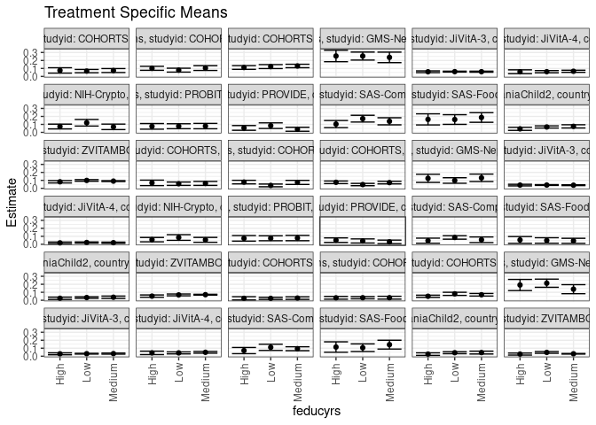

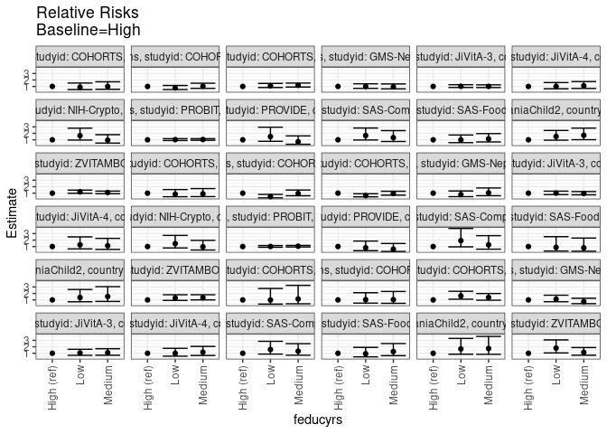

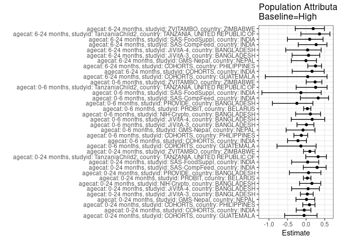

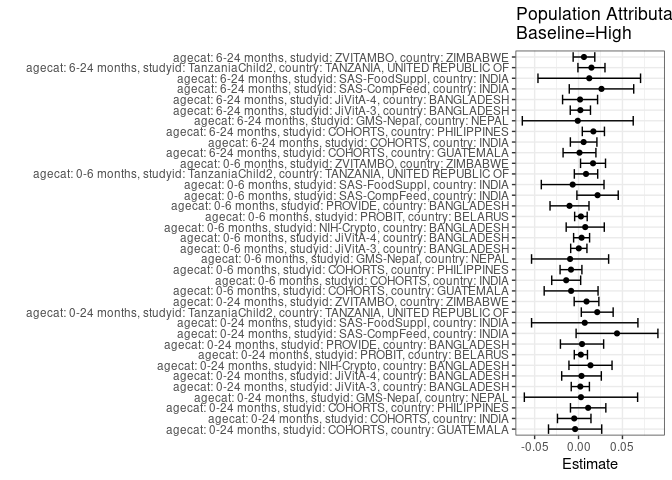

## Results Table

### Parameter: TSM

| agecat | studyid | country | intervention_level | baseline_level | estimate | ci_lower | ci_upper |
| --- | --- | --- | --- | --- | --- | --- | --- |
| 0-24 months | COHORTS | GUATEMALA | High | NA | 0.0752212 | 0.0414547 | 0.1089877 |
| 0-24 months | COHORTS | GUATEMALA | Low | NA | 0.0666798 | 0.0459968 | 0.0873628 |
| 0-24 months | COHORTS | GUATEMALA | Medium | NA | 0.0738496 | 0.0491509 | 0.0985483 |
| 0-24 months | COHORTS | INDIA | High | NA | 0.1016868 | 0.0768716 | 0.1265019 |
| 0-24 months | COHORTS | INDIA | Low | NA | 0.0786919 | 0.0543017 | 0.1030821 |
| 0-24 months | COHORTS | INDIA | Medium | NA | 0.1047093 | 0.0750342 | 0.1343844 |
| 0-24 months | COHORTS | PHILIPPINES | High | NA | 0.1118003 | 0.0888864 | 0.1347141 |
| 0-24 months | COHORTS | PHILIPPINES | Low | NA | 0.1233663 | 0.0984631 | 0.1482695 |
| 0-24 months | COHORTS | PHILIPPINES | Medium | NA | 0.1310539 | 0.1093030 | 0.1528047 |
| 0-24 months | GMS-Nepal | NEPAL | High | NA | 0.2560100 | 0.1841672 | 0.3278528 |
| 0-24 months | GMS-Nepal | NEPAL | Low | NA | 0.2553321 | 0.2053223 | 0.3053419 |
| 0-24 months | GMS-Nepal | NEPAL | Medium | NA | 0.2386471 | 0.1728349 | 0.3044592 |
| 0-24 months | JiVitA-3 | BANGLADESH | High | NA | 0.0585092 | 0.0475193 | 0.0694990 |
| 0-24 months | JiVitA-3 | BANGLADESH | Low | NA | 0.0601277 | 0.0540169 | 0.0662385 |
| 0-24 months | JiVitA-3 | BANGLADESH | Medium | NA | 0.0592648 | 0.0526033 | 0.0659264 |
| 0-24 months | JiVitA-4 | BANGLADESH | High | NA | 0.0585948 | 0.0345759 | 0.0826137 |
| 0-24 months | JiVitA-4 | BANGLADESH | Low | NA | 0.0595335 | 0.0456533 | 0.0734137 |
| 0-24 months | JiVitA-4 | BANGLADESH | Medium | NA | 0.0648075 | 0.0515256 | 0.0780895 |
| 0-24 months | NIH-Crypto | BANGLADESH | High | NA | 0.0734718 | 0.0435511 | 0.1033925 |
| 0-24 months | NIH-Crypto | BANGLADESH | Low | NA | 0.1206878 | 0.0793013 | 0.1620743 |
| 0-24 months | NIH-Crypto | BANGLADESH | Medium | NA | 0.0693317 | 0.0348714 | 0.1037919 |
| 0-24 months | PROBIT | BELARUS | High | NA | 0.0754417 | 0.0401653 | 0.1107181 |
| 0-24 months | PROBIT | BELARUS | Low | NA | 0.0771584 | 0.0460037 | 0.1083131 |
| 0-24 months | PROBIT | BELARUS | Medium | NA | 0.0788483 | 0.0451409 | 0.1125557 |
| 0-24 months | PROVIDE | BANGLADESH | High | NA | 0.0560345 | 0.0264189 | 0.0856501 |
| 0-24 months | PROVIDE | BANGLADESH | Low | NA | 0.0840336 | 0.0487611 | 0.1193061 |
| 0-24 months | PROVIDE | BANGLADESH | Medium | NA | 0.0391304 | 0.0140529 | 0.0642079 |
| 0-24 months | SAS-CompFeed | INDIA | High | NA | 0.1038832 | 0.0591772 | 0.1485891 |
| 0-24 months | SAS-CompFeed | INDIA | Low | NA | 0.1719590 | 0.1296650 | 0.2142529 |
| 0-24 months | SAS-CompFeed | INDIA | Medium | NA | 0.1388890 | 0.0945510 | 0.1832271 |

[output cut: 78 more lines]

### Parameter: E(Y)

| agecat | studyid | country | intervention_level | baseline_level | estimate | ci_lower | ci_upper |
| --- | --- | --- | --- | --- | --- | --- | --- |
| 0-24 months | COHORTS | GUATEMALA | NA | NA | 0.0713128 | 0.0569485 | 0.0856771 |
| 0-24 months | COHORTS | INDIA | NA | NA | 0.0967519 | 0.0815150 | 0.1119888 |
| 0-24 months | COHORTS | PHILIPPINES | NA | NA | 0.1227336 | 0.1107225 | 0.1347447 |
| 0-24 months | GMS-Nepal | NEPAL | NA | NA | 0.2587719 | 0.2259267 | 0.2916172 |
| 0-24 months | JiVitA-3 | BANGLADESH | NA | NA | 0.0605314 | 0.0569870 | 0.0640758 |
| 0-24 months | JiVitA-4 | BANGLADESH | NA | NA | 0.0619670 | 0.0548012 | 0.0691329 |
| 0-24 months | NIH-Crypto | BANGLADESH | NA | NA | 0.0870712 | 0.0669870 | 0.1071555 |
| 0-24 months | PROBIT | BELARUS | NA | NA | 0.0780876 | 0.0455813 | 0.1105940 |
| 0-24 months | PROVIDE | BANGLADESH | NA | NA | 0.0600000 | 0.0423945 | 0.0776055 |
| 0-24 months | SAS-CompFeed | INDIA | NA | NA | 0.1476821 | 0.1188009 | 0.1765633 |
| 0-24 months | SAS-FoodSuppl | INDIA | NA | NA | 0.1698565 | 0.1338154 | 0.2058975 |
| 0-24 months | TanzaniaChild2 | TANZANIA, UNITED REPUBLIC OF | NA | NA | 0.0658833 | 0.0559209 | 0.0758458 |
| 0-24 months | ZVITAMBO | ZIMBABWE | NA | NA | 0.0912441 | 0.0863987 | 0.0960895 |
| 0-6 months | COHORTS | GUATEMALA | NA | NA | 0.0601805 | 0.0454109 | 0.0749501 |
| 0-6 months | COHORTS | INDIA | NA | NA | 0.0642202 | 0.0514517 | 0.0769887 |
| 0-6 months | COHORTS | PHILIPPINES | NA | NA | 0.0669690 | 0.0578174 | 0.0761205 |
| 0-6 months | GMS-Nepal | NEPAL | NA | NA | 0.1154971 | 0.0915268 | 0.1394673 |
| 0-6 months | JiVitA-3 | BANGLADESH | NA | NA | 0.0411097 | 0.0380745 | 0.0441448 |
| 0-6 months | JiVitA-4 | BANGLADESH | NA | NA | 0.0212207 | 0.0163071 | 0.0261342 |
| 0-6 months | NIH-Crypto | BANGLADESH | NA | NA | 0.0659631 | 0.0482810 | 0.0836451 |
| 0-6 months | PROBIT | BELARUS | NA | NA | 0.0773664 | 0.0448152 | 0.1099175 |
| 0-6 months | PROVIDE | BANGLADESH | NA | NA | 0.0414286 | 0.0266555 | 0.0562017 |
| 0-6 months | SAS-CompFeed | INDIA | NA | NA | 0.0665779 | 0.0427569 | 0.0903989 |
| 0-6 months | SAS-FoodSuppl | INDIA | NA | NA | 0.0478469 | 0.0273607 | 0.0683330 |
| 0-6 months | TanzaniaChild2 | TANZANIA, UNITED REPUBLIC OF | NA | NA | 0.0331515 | 0.0259618 | 0.0403411 |
| 0-6 months | ZVITAMBO | ZIMBABWE | NA | NA | 0.0681110 | 0.0638575 | 0.0723645 |
| 6-24 months | COHORTS | GUATEMALA | NA | NA | 0.0248889 | 0.0157815 | 0.0339963 |
| 6-24 months | COHORTS | INDIA | NA | NA | 0.0362989 | 0.0265157 | 0.0460822 |
| 6-24 months | COHORTS | PHILIPPINES | NA | NA | 0.0666667 | 0.0571766 | 0.0761568 |
| 6-24 months | GMS-Nepal | NEPAL | NA | NA | 0.1901528 | 0.1584343 | 0.2218713 |
| 6-24 months | JiVitA-3 | BANGLADESH | NA | NA | 0.0317355 | 0.0287378 | 0.0347333 |
| 6-24 months | JiVitA-4 | BANGLADESH | NA | NA | 0.0434288 | 0.0375191 | 0.0493385 |
| 6-24 months | SAS-CompFeed | INDIA | NA | NA | 0.0966811 | 0.0731505 | 0.1202117 |
| 6-24 months | SAS-FoodSuppl | INDIA | NA | NA | 0.1268657 | 0.0942904 | 0.1594410 |
| 6-24 months | TanzaniaChild2 | TANZANIA, UNITED REPUBLIC OF | NA | NA | 0.0408163 | 0.0321620 | 0.0494707 |
| 6-24 months | ZVITAMBO | ZIMBABWE | NA | NA | 0.0324638 | 0.0290744 | 0.0358532 |

### Parameter: RR

| agecat | studyid | country | intervention_level | baseline_level | estimate | ci_lower | ci_upper |
| --- | --- | --- | --- | --- | --- | --- | --- |
| 0-24 months | COHORTS | GUATEMALA | High | High | 1.0000000 | 1.0000000 | 1.0000000 |
| 0-24 months | COHORTS | GUATEMALA | Low | High | 0.8864494 | 0.5142308 | 1.5280933 |
| 0-24 months | COHORTS | GUATEMALA | Medium | High | 0.9817656 | 0.5611999 | 1.7175051 |
| 0-24 months | COHORTS | INDIA | High | High | 1.0000000 | 1.0000000 | 1.0000000 |
| 0-24 months | COHORTS | INDIA | Low | High | 0.7738655 | 0.5214848 | 1.1483898 |
| 0-24 months | COHORTS | INDIA | Medium | High | 1.0297241 | 0.7082515 | 1.4971118 |
| 0-24 months | COHORTS | PHILIPPINES | High | High | 1.0000000 | 1.0000000 | 1.0000000 |
| 0-24 months | COHORTS | PHILIPPINES | Low | High | 1.1034526 | 0.8313158 | 1.4646751 |
| 0-24 months | COHORTS | PHILIPPINES | Medium | High | 1.1722141 | 0.9065447 | 1.5157399 |
| 0-24 months | GMS-Nepal | NEPAL | High | High | 1.0000000 | 1.0000000 | 1.0000000 |
| 0-24 months | GMS-Nepal | NEPAL | Low | High | 0.9973521 | 0.7080819 | 1.4047970 |
| 0-24 months | GMS-Nepal | NEPAL | Medium | High | 0.9321788 | 0.6288556 | 1.3818075 |
| 0-24 months | JiVitA-3 | BANGLADESH | High | High | 1.0000000 | 1.0000000 | 1.0000000 |
| 0-24 months | JiVitA-3 | BANGLADESH | Low | High | 1.0276627 | 0.8364057 | 1.2626536 |
| 0-24 months | JiVitA-3 | BANGLADESH | Medium | High | 1.0129153 | 0.8245612 | 1.2442949 |
| 0-24 months | JiVitA-4 | BANGLADESH | High | High | 1.0000000 | 1.0000000 | 1.0000000 |
| 0-24 months | JiVitA-4 | BANGLADESH | Low | High | 1.0160203 | 0.6450402 | 1.6003612 |
| 0-24 months | JiVitA-4 | BANGLADESH | Medium | High | 1.1060286 | 0.6980506 | 1.7524508 |
| 0-24 months | NIH-Crypto | BANGLADESH | High | High | 1.0000000 | 1.0000000 | 1.0000000 |
| 0-24 months | NIH-Crypto | BANGLADESH | Low | High | 1.6426406 | 0.9642289 | 2.7983692 |
| 0-24 months | NIH-Crypto | BANGLADESH | Medium | High | 0.9436498 | 0.4962045 | 1.7945723 |
| 0-24 months | PROBIT | BELARUS | High | High | 1.0000000 | 1.0000000 | 1.0000000 |
| 0-24 months | PROBIT | BELARUS | Low | High | 1.0227553 | 0.8891935 | 1.1763789 |
| 0-24 months | PROBIT | BELARUS | Medium | High | 1.0451556 | 0.9286044 | 1.1763354 |
| 0-24 months | PROVIDE | BANGLADESH | High | High | 1.0000000 | 1.0000000 | 1.0000000 |
| 0-24 months | PROVIDE | BANGLADESH | Low | High | 1.4996768 | 0.7636284 | 2.9451898 |
| 0-24 months | PROVIDE | BANGLADESH | Medium | High | 0.6983278 | 0.3042943 | 1.6025988 |
| 0-24 months | SAS-CompFeed | INDIA | High | High | 1.0000000 | 1.0000000 | 1.0000000 |
| 0-24 months | SAS-CompFeed | INDIA | Low | High | 1.6553113 | 0.9713904 | 2.8207564 |
| 0-24 months | SAS-CompFeed | INDIA | Medium | High | 1.3369736 | 0.7388163 | 2.4194086 |

[output cut: 78 more lines]

### Parameter: PAR

| agecat | studyid | country | intervention_level | baseline_level | estimate | ci_lower | ci_upper |
| --- | --- | --- | --- | --- | --- | --- | --- |
| 0-24 months | COHORTS | GUATEMALA | High | NA | -0.0039084 | -0.0342169 | 0.0264001 |
| 0-24 months | COHORTS | INDIA | High | NA | -0.0049349 | -0.0240088 | 0.0141391 |
| 0-24 months | COHORTS | PHILIPPINES | High | NA | 0.0109333 | -0.0092155 | 0.0310822 |
| 0-24 months | GMS-Nepal | NEPAL | High | NA | 0.0027619 | -0.0617435 | 0.0672674 |
| 0-24 months | JiVitA-3 | BANGLADESH | High | NA | 0.0020222 | -0.0083180 | 0.0123624 |
| 0-24 months | JiVitA-4 | BANGLADESH | High | NA | 0.0033722 | -0.0191945 | 0.0259389 |
| 0-24 months | NIH-Crypto | BANGLADESH | High | NA | 0.0135994 | -0.0109370 | 0.0381358 |
| 0-24 months | PROBIT | BELARUS | High | NA | 0.0026460 | -0.0048583 | 0.0101502 |
| 0-24 months | PROVIDE | BANGLADESH | High | NA | 0.0039655 | -0.0206446 | 0.0285756 |
| 0-24 months | SAS-CompFeed | INDIA | High | NA | 0.0437990 | -0.0027863 | 0.0903842 |
| 0-24 months | SAS-FoodSuppl | INDIA | High | NA | 0.0070534 | -0.0535047 | 0.0676116 |
| 0-24 months | TanzaniaChild2 | TANZANIA, UNITED REPUBLIC OF | High | NA | 0.0212787 | 0.0031492 | 0.0394081 |
| 0-24 months | ZVITAMBO | ZIMBABWE | High | NA | 0.0090797 | -0.0049691 | 0.0231285 |
| 0-6 months | COHORTS | GUATEMALA | High | NA | -0.0084668 | -0.0391399 | 0.0222064 |
| 0-6 months | COHORTS | INDIA | High | NA | -0.0140665 | -0.0305506 | 0.0024175 |
| 0-6 months | COHORTS | PHILIPPINES | High | NA | -0.0086040 | -0.0210328 | 0.0038249 |
| 0-6 months | GMS-Nepal | NEPAL | High | NA | -0.0096306 | -0.0535155 | 0.0342543 |
| 0-6 months | JiVitA-3 | BANGLADESH | High | NA | 0.0002991 | -0.0089545 | 0.0095526 |
| 0-6 months | JiVitA-4 | BANGLADESH | High | NA | 0.0034708 | -0.0056274 | 0.0125690 |
| 0-6 months | NIH-Crypto | BANGLADESH | High | NA | 0.0076092 | -0.0140891 | 0.0293075 |
| 0-6 months | PROBIT | BELARUS | High | NA | 0.0026988 | -0.0044398 | 0.0098374 |
| 0-6 months | PROVIDE | BANGLADESH | High | NA | -0.0102956 | -0.0324867 | 0.0118956 |
| 0-6 months | SAS-CompFeed | INDIA | High | NA | 0.0216546 | -0.0018794 | 0.0451886 |
| 0-6 months | SAS-FoodSuppl | INDIA | High | NA | -0.0066986 | -0.0424031 | 0.0290059 |
| 0-6 months | TanzaniaChild2 | TANZANIA, UNITED REPUBLIC OF | High | NA | 0.0085049 | -0.0047977 | 0.0218075 |
| 0-6 months | ZVITAMBO | ZIMBABWE | High | NA | 0.0164897 | 0.0022631 | 0.0307164 |
| 6-24 months | COHORTS | GUATEMALA | High | NA | 0.0010794 | -0.0176188 | 0.0197775 |
| 6-24 months | COHORTS | INDIA | High | NA | 0.0057919 | -0.0093177 | 0.0209015 |
| 6-24 months | COHORTS | PHILIPPINES | High | NA | 0.0168801 | 0.0042666 | 0.0294937 |
| 6-24 months | GMS-Nepal | NEPAL | High | NA | -0.0008871 | -0.0640400 | 0.0622658 |
| 6-24 months | JiVitA-3 | BANGLADESH | High | NA | 0.0020753 | -0.0094319 | 0.0135825 |
| 6-24 months | JiVitA-4 | BANGLADESH | High | NA | 0.0017484 | -0.0181802 | 0.0216769 |
| 6-24 months | SAS-CompFeed | INDIA | High | NA | 0.0261299 | -0.0105669 | 0.0628267 |
| 6-24 months | SAS-FoodSuppl | INDIA | High | NA | 0.0122020 | -0.0462138 | 0.0706178 |
| 6-24 months | TanzaniaChild2 | TANZANIA, UNITED REPUBLIC OF | High | NA | 0.0146959 | -0.0007098 | 0.0301016 |
| 6-24 months | ZVITAMBO | ZIMBABWE | High | NA | 0.0061684 | -0.0061446 | 0.0184814 |

### Parameter: PAF

| agecat | studyid | country | intervention_level | baseline_level | estimate | ci_lower | ci_upper |
| --- | --- | --- | --- | --- | --- | --- | --- |
| 0-24 months | COHORTS | GUATEMALA | High | NA | -0.0548065 | -0.5781202 | 0.2949734 |
| 0-24 months | COHORTS | INDIA | High | NA | -0.0510054 | -0.2677173 | 0.1286604 |
| 0-24 months | COHORTS | PHILIPPINES | High | NA | 0.0890819 | -0.0905426 | 0.2391202 |
| 0-24 months | GMS-Nepal | NEPAL | High | NA | 0.0106732 | -0.2727913 | 0.2310071 |
| 0-24 months | JiVitA-3 | BANGLADESH | High | NA | 0.0334076 | -0.1534959 | 0.1900268 |
| 0-24 months | JiVitA-4 | BANGLADESH | High | NA | 0.0544196 | -0.3903668 | 0.3569163 |
| 0-24 months | NIH-Crypto | BANGLADESH | High | NA | 0.1561871 | -0.1759578 | 0.3945190 |
| 0-24 months | PROBIT | BELARUS | High | NA | 0.0338846 | -0.0723835 | 0.1296220 |
| 0-24 months | PROVIDE | BANGLADESH | High | NA | 0.0660920 | -0.4482931 | 0.3977847 |
| 0-24 months | SAS-CompFeed | INDIA | High | NA | 0.2965759 | -0.0754859 | 0.5399238 |
| 0-24 months | SAS-FoodSuppl | INDIA | High | NA | 0.0415259 | -0.3901128 | 0.3391381 |
| 0-24 months | TanzaniaChild2 | TANZANIA, UNITED REPUBLIC OF | High | NA | 0.3229747 | -0.0104185 | 0.5463630 |
| 0-24 months | ZVITAMBO | ZIMBABWE | High | NA | 0.0995097 | -0.0684347 | 0.2410554 |
| 0-6 months | COHORTS | GUATEMALA | High | NA | -0.1406893 | -0.7837030 | 0.2705220 |
| 0-6 months | COHORTS | INDIA | High | NA | -0.2190360 | -0.5005553 | 0.0096675 |
| 0-6 months | COHORTS | PHILIPPINES | High | NA | -0.1284770 | -0.3289028 | 0.0417205 |
| 0-6 months | GMS-Nepal | NEPAL | High | NA | -0.0833837 | -0.5381879 | 0.2369461 |
| 0-6 months | JiVitA-3 | BANGLADESH | High | NA | 0.0072750 | -0.2454545 | 0.2087202 |
| 0-6 months | JiVitA-4 | BANGLADESH | High | NA | 0.1635562 | -0.4012375 | 0.5006998 |
| 0-6 months | NIH-Crypto | BANGLADESH | High | NA | 0.1153555 | -0.2822542 | 0.3896718 |
| 0-6 months | PROBIT | BELARUS | High | NA | 0.0348836 | -0.0669293 | 0.1269808 |
| 0-6 months | PROVIDE | BANGLADESH | High | NA | -0.2485137 | -0.9073454 | 0.1827456 |
| 0-6 months | SAS-CompFeed | INDIA | High | NA | 0.3252524 | -0.1519484 | 0.6047703 |
| 0-6 months | SAS-FoodSuppl | INDIA | High | NA | -0.1400000 | -1.1896425 | 0.4064785 |
| 0-6 months | TanzaniaChild2 | TANZANIA, UNITED REPUBLIC OF | High | NA | 0.2565465 | -0.2686091 | 0.5643078 |
| 0-6 months | ZVITAMBO | ZIMBABWE | High | NA | 0.2421009 | 0.0019656 | 0.4244577 |
| 6-24 months | COHORTS | GUATEMALA | High | NA | 0.0433673 | -1.0976561 | 0.5637292 |
| 6-24 months | COHORTS | INDIA | High | NA | 0.1595606 | -0.3757409 | 0.4865760 |
| 6-24 months | COHORTS | PHILIPPINES | High | NA | 0.2532017 | 0.0439873 | 0.4166315 |
| 6-24 months | GMS-Nepal | NEPAL | High | NA | -0.0046651 | -0.3982903 | 0.2781527 |
| 6-24 months | JiVitA-3 | BANGLADESH | High | NA | 0.0653929 | -0.3776195 | 0.3659422 |
| 6-24 months | JiVitA-4 | BANGLADESH | High | NA | 0.0402583 | -0.5490483 | 0.4053741 |
| 6-24 months | SAS-CompFeed | INDIA | High | NA | 0.2702691 | -0.2124309 | 0.5607937 |
| 6-24 months | SAS-FoodSuppl | INDIA | High | NA | 0.0961806 | -0.5032495 | 0.4565842 |
| 6-24 months | TanzaniaChild2 | TANZANIA, UNITED REPUBLIC OF | High | NA | 0.3600494 | -0.1408801 | 0.6410344 |
| 6-24 months | ZVITAMBO | ZIMBABWE | High | NA | 0.1900089 | -0.2928262 | 0.4925184 |